# TEMPEST Porewater FTICRMS Processing

AMP

2025-03-20

Notes from EMSL:

Two of the supplicate runs were much lower than the original run. I would discard these r2 data files.

- EUP_60602_TMP_C_POOL_T4_r2_25Sep23_Fir_450SA
- EUP_60602_TMP_SW_SOURCE_HR2_r2_25Sep23_Fir_450SA
- Peak assignments for CHOS, CHOP, and CHON in certain areas of the formularity output have been recommended to be removed by EMSL staff
- need to filter the mass error > 0.5 and < -0.5

These functions have been modified from the `fticrrr` package and workflow: https://github.com/kaizadp/fticrrr

## 1. Set input file paths

Local version file path… here read_csv(“../TEMPEST-1-porewater/data_do_not_commit/fticrms/ReportforCOMPASS_Nov2023/xtra_COMPASS_60602_2023_Report.csv”)

However, best practice is for L0 data to be on google drive, so download it from there:

```r
REPORT_path = "https://drive.google.com/drive/folders/1hEmD6CnQlojRYug-3eMHpTFzzBso5-8c"

import_data = function(directory){

  ## a. Create a list of files to download
  files <-
    drive_ls(directory) %>%
    filter(grepl("xtra_COMPASS_60602_2023_Report.csv", name))

  ## b. Download files to local (don't worry, we'll delete em in a sec)
  lapply(files$id, drive_download, overwrite = TRUE)

  dat <- read_csv(files$name)


  ## c. pull a list of file names
  ## then read all files and combine
  #
  # filePaths <- files$id
  # dat <-
  #   do.call(rbind, lapply(filePaths, function(path){
  #     # then add a new column `source` to denote the file name
  #     df <- read.csv(files$name)
  #     #  df <- read.delim(path, skip = 2)
  #     df[["source"]] <- rep(path, nrow(df))
  #     df}))
  #
  ## d. delete the temporary files
  file.remove(c(files$name))

  ## e. output
  dat
}
```

### 1b. Create sample metadata keys

```r
sample_list_1 <- readxl::read_excel("../TEMPEST-1-porewater/sample lists/Myers-Pigg_TEMPEST_FT_samplelist_Sept2023.xlsx") %>%
  mutate(sample_name = stringr::str_replace(Sample_ID,"pooled","POOL"),
         sample_name = stringr::str_replace(Sample_ID,"Source","SOURCE"),
         sample_name = stringr::str_remove(sample_name, "_FW\\d{2}|_SW\\d{2}"))

sample_list = sample_list_1 %>%
  select(sample_name)

sample_key <- readRDS("~/GitHub/tempest-system-level-analysis/data/for processing/TMP_Event_June2022_META_PW_SOURCE_DateTime.rds") %>%
  mutate(Grid = case_when(is.na(Grid) ~ "POOL",
                          TRUE ~ Grid))

non_event_sample_key <- readxl::read_excel("~/GitHub/TEMPEST-1-porewater/data_do_not_commit/porewaterinventory.xlsx", skip=3, sheet="Porewater - Individual") %>%
  select(Sample_ID, Evacuation_date_YYYMMDD, Collection_Date_YYYYMMDD, Collection_End_Time_24hrs, EST_EDT) %>%
  filter(str_detect(Sample_ID, "DOC")) %>%
  rename(sample_name = Sample_ID,
         evacuation_date = Evacuation_date_YYYMMDD,
         collection_date = Collection_Date_YYYYMMDD,
         time = Collection_End_Time_24hrs,
         tz = EST_EDT) %>%
  mutate(evacuation_date = lubridate::as_date(as.character(evacuation_date), format = "%Y%m%d"),
         collection_date = lubridate::as_date(as.character(collection_date), format = "%Y%m%d"),
         elapsed_time = lubridate::days(collection_date - evacuation_date)) %>%
  select(sample_name, evacuation_date, collection_date, time, tz, elapsed_time)

## add into here time points for pre and post sampling for gapfilling purposes later on
estuary_key1 = tibble(Plot = "ESTUARY",
                     Timepoint = "HR4",
                     date = "20220622",
                     time= "110000")

estuary_key2 = tibble(Plot = "ESTUARY",
                     Timepoint = "HR7",
                     date = "20220622",
                     time= "150000")

sample_key_merging <- sample_key %>%
  mutate(date = stringr::str_remove_all(Date, "-")) %>%
  rename(time = Start_time) %>%
  mutate(time = str_replace_all(time, ":", "")) %>%
  select(Plot,Timepoint, date, time) %>%
  bind_rows(estuary_key1,estuary_key2) %>%
  mutate(time = str_replace(time, "^[0-9]{5}$", function(x) paste0("0",x)))

non_event_sample_key_merging <- non_event_sample_key %>%
  mutate(Plot = stringr::str_extract(sample_name, 'FW|SW|C|ESTUARY'),
         Grid = stringr::str_extract(sample_name, "B4|C3|C6|D5|E3|F4|F6|H3|H6|I5|SOURCE|ESTUARY|POOL|WELL"),
         date = stringr::str_extract(sample_name, "[0-9]{8}"),
         time = str_replace(time, "^[0-9]{3}$", function(x) paste0("0", x, "00")),
         time = str_replace(time, "^[0-9]{4}$", function(x) paste0(x, "00"))
         ) %>%
  select(Plot, date, time, tz, evacuation_date, collection_date) %>%
  group_by(Plot, date) %>%
  arrange(time) %>% # Ensure time is ordered within each group
  slice(1) %>% # Keep the first row within each group
  ungroup()

sample_list_allmeta <- sample_list %>%
     mutate(sample_name = stringr::str_replace(sample_name,"pooled","POOL"),
         Event = stringr::str_extract(sample_name, "TMP"),
         Plot = stringr::str_extract(sample_name, 'FW|SW|C|ESTUARY'),
         Grid = stringr::str_extract(sample_name, "B4|C3|C6|D5|E3|F4|F6|H3|H6|I5|SOURCE|ESTUARY|POOL|WELL"),
         Timepoint = stringr::str_extract(sample_name,"T[0-9]|HR[0-9]"),
         Timepoint = case_when(Timepoint == "HR8" ~ "HR7", #change the estuary HR8 to HR7
                                TRUE ~ Timepoint),
         Pool_Timepoint = stringr::str_extract(sample_name,"[0-9]{8}_\\d{8}|[0-9]{8}-\\d{8}"),
         #sample_name = stringr::str_remove(sample_name,"(?<=[0-9]{8})_\\d{8}|(?<=[0-9]{8})-\\d{8}"),
         sample_name = stringr::str_remove(sample_name, "_FW\\d{2}|_SW\\d{2}")
         ) %>%
   mutate(Plot = case_when(Grid == "ESTUARY" ~ "ESTUARY",
                        TRUE ~ Plot)) %>%
  left_join(sample_key_merging, by = c("Plot","Timepoint")) %>%
  mutate(date= case_when(is.na(date) ~ stringr::str_extract(sample_name, "[0-9]{8}"),
                  TRUE ~ date)) %>%
 left_join(non_event_sample_key_merging, by= c("Plot", "date"), suffix = c("", ".fill")) %>%
  mutate(time = coalesce(time, time.fill)) %>%
  select(-time.fill) %>%
  mutate(date = lubridate::as_date(date, format = "%Y%m%d")) %>%
  mutate(Timepoint = case_when(is.na(Timepoint) & date == "2022-07-18" ~ "T5",
                             is.na(Timepoint) & date == "2022-07-21" ~ "T5",
                             is.na(Timepoint) & date == "2022-06-15" ~ "T0",
                                      TRUE ~ Timepoint)) %>%
  mutate(time = case_when(is.na(time) ~ "115900",
                          TRUE ~ time)) %>% #if no time recorded in the metadata sheet, fill in with noon
  mutate(time= strptime(time, format ="%H%M%S"),
         time = strftime(time, "%H:%M:%S")) %>%
    mutate(datetime = as.POSIXct(paste(date, time), format = "%Y-%m-%d %H:%M:%S"))
```

## 2. source the fticrr functions ——————————————————–

```r
source("../TEMPEST_Porewater/processing_scripts/FTICRMS/fticrrr_processing_scripts/a-functions_processing.R")
```

## 3. import and do first level cleaning of the raw data file

need to filter the mass error > 0.5 and < -0.5

```r
REPORT = import_data(REPORT_path) %>% bind_rows()
```

[output not shown]

[output not shown]

[output not shown]

[output not shown]

```
## File downloaded:
```

```
## • 'xtra_COMPASS_60602_2023_Report.csv' <id: 1_KCVtReIDJAhW5IZqxGCSwMuVcgMF701>
```

```
## Saved locally as:
```

```
## • 'xtra_COMPASS_60602_2023_Report.csv'
```

```r
# Remove the samples EMSL said to remove:

report = REPORT %>%
  #remove the samples Rosey said to
  select(-TMP_C_POOL_T4_r2_25S, -TMP_SW_SOURCE_HR2_r2_25S) %>%
  #remove the emsl worked up columns at the end:
  select(-(kmd:`cho-ind`), -...142, -class) %>%
    filter(Error_ppm < 0.5 & Error_ppm > -0.5)

# Trim mass range, remove isotope peaks, and remove unidentified molecular formula

fticr_report = apply_filter_report(report)

fticr_report
```

```
## # A tibble: 53,400 × 139
##     Mass     C     H     O     N   C13     S     P    Na El_comp Class
##    <dbl> <dbl> <dbl> <dbl> <dbl> <dbl> <dbl> <dbl> <dbl> <chr>   <chr>
##  1  220.    10     7     5     1     0     0     0     0 CHON    ConHC
##  2  220.     7    12     5     1     0     0     1     0 CHONP   Carb
##  3  220.    11    11     4     1     0     0     0     0 CHON    Lignin
##  4  221.     8    14     7     0     0     0     0     0 CHO     Carb
##  5  221.    10    23     3     0     0     0     1     0 CHOP    Other
##  6  222.    11    13     4     1     0     0     0     0 CHON    Lignin
##  7  222.    12    17     1     1     0     1     0     0 CHONS   UnsatHC
##  8  222.    12    17     3     1     0     0     0     0 CHON    Lignin
##  9  223.     9     4     7     0     0     0     0     0 CHO     ConHC
## 10  223.    10     8     6     0     0     0     0     0 CHO     Lignin
## # ℹ 53,390 more rows
## # ℹ 128 more variables: NeutralMass <dbl>, Error_ppm <dbl>, Candidates <dbl>,
## #   TMP_SW_POOL_20220613_r2 <dbl>, TMP_FW_POOL_20230417_r2 <dbl>,
## #   TMP_FW_POOL_T4_r2 <dbl>, TMP_SW_POOL_20220523_r2 <dbl>,
## #   TMP_SW_POOL_T4_r2 <dbl>, TMP_SW_POOL_20230202_r2 <dbl>,
## #   TMP_C_POOL_20230515_r2 <dbl>, TMP_FW_POOL_20220718_r2 <dbl>,
## #   TMP_FW_SOURCE_HR0_r2 <dbl>, TMP_C_POOL_20221019_20221024_r2 <dbl>, …
```

# 4. Create Sample Meadata

This section creates FTICR metadata. It calculates various relevant indices (e.g. AImod, DBE, etc) and creates the molecular formula (e.g. C6H9O).

```r
fticr_meta = make_fticr_meta(fticr_report)$meta2

nrow(fticr_meta)
```

```
## [1] 52416
```

It also checks if you have the same formula assigned to multiple masses. If so, then you need to aggregate across the multiple masses.

```r
#total number of reported masses:

mass_to_formula = make_fticr_meta(fticr_report)$meta_formula

unique_masses <- mass_to_formula %>% select(Mass) %>%
  distinct()

nrow(unique_masses)
```

```
## [1] 53400
```

```r
# number of unique formula:

unique_formula <- mass_to_formula %>% select(formula) %>%
  distinct()

nrow(unique_formula)
```

```
## [1] 52416
```

If nrow(unique_masses) ≠ nrow(unique_formula) then you’ll need to aggregate the data based on unique MFs at some point.

## Step 5. Isolate sample and blank data and aggregate:

```r
# Remove all data but the Mass and Sample data

fticr_samples <- fticr_report %>%
  select(-c(C:Candidates))

nrow(fticr_samples)
```

```
## [1] 53400
```

```r
# Merges sample data with filtered metadata.
fticr_samples_formula <- merge(x=mass_to_formula, y=fticr_samples, by="Mass", all.x=TRUE)

nrow(fticr_samples_formula)
```

```
## [1] 53400
```

```r
# Reorder columns to put the molecular formula in the first column and remove columns other than the elemental formula and the sample data.
fticr_samples_all <- fticr_samples_formula %>%
  select(formula,everything())

nrow(fticr_samples_all)
```

```
## [1] 53400
```

```r
#aggregate function to remove and merge duplicate rows

meta_agg <- aggregate(.~formula, data=mass_to_formula, mean) #aggregates metadata and takes the mean of duplicate rows with the same molecular formula.

#This ensures there are no changes in the metadata and only the merging of rows

fticr_samples_agg <- aggregate(.~ formula,data=fticr_samples_all, sum) #aggregates the metadata and samples to merge rows with the same molecular formula. We keep the metadata in here

#to ensure the metadata and samples are merged consistently. Duplicated molecular formula will have their intensities summed.

formula_check <- fticr_samples_agg %>% select(formula) %>% distinct()

nrow(formula_check) #this should be the same as the nrow(unique_formula) and nrow(fticr_meta) if everything goes well.
```

```
## [1] 52416
```

```r
fticr_samples_agg_meta <- fticr_samples_agg %>%
  full_join(fticr_meta, by= "formula")

fticr_samples_agg_mass <- fticr_samples_agg %>% select(-formula)

mass_to_formula_agg <- fticr_samples_agg %>%
  select(Mass, formula)

nrow(mass_to_formula_agg)
```

```
## [1] 52416
```

## Step 6. Clean data: Long format, remove blank signals, and only retain MFs that are in both reps.

```r
#make data long form and get the reps into a common sample name:

reps_suffix = "_[A-Za-z0-9]+$"

data_long_key = compute_presence(fticr_samples_agg_mass) %>%
    left_join(mass_to_formula_agg, by = "Mass") %>%
    dplyr::select(formula, Sample_ID, presence) %>%
    mutate(sample_name = str_replace_all(Sample_ID, reps_suffix, "")) %>%
    mutate(sample_name = str_replace_all(sample_name, "_[A-Za-z]$", "")) %>%
    mutate(sample_name = str_replace_all(sample_name, "_[0-9]$", "")) %>%
    mutate(sample_name = stringr::str_replace(sample_name,"pooled","POOL"),
           sample_name = stringr::str_replace(sample_name,"Source","SOURCE")) %>%
    left_join(sample_list, by = "sample_name")

nrow(data_long_key)
```

```
## [1] 1311268
```

```r
# Filter out the blanks, so that we can remove MFs present in any of the blanks:

data_long_key_blanks_mfs <- data_long_key %>%
  filter(str_detect(sample_name, regex("blank", ignore_case = TRUE))) %>%
  distinct(formula)

data_long_key_blanks_mfs
```

```
## # A tibble: 10,829 × 1
##    formula
##    <chr>
##  1 C10H10O6
##  2 C10H10O7
##  3 C10H10O8
##  4 C10H10O9
##  5 C10H11O11N4S1P1
##  6 C10H11O2S1P1
##  7 C10H11O3N1S1
##  8 C10H11O5N1
##  9 C10H11O6N1
## 10 C10H11O8N3
## # ℹ 10,819 more rows
```

```r
# Group by sample_name and filter to only display the formulas that appear in all reps

data_long_key_counts = data_long_key %>%
    group_by(sample_name, formula) %>%
    summarise(count_reps = n_distinct(Sample_ID), .groups = 'drop') %>%
    filter(count_reps > 1) %>%
    arrange(sample_name, formula)

nrow(data_long_key_counts)
```

```
## [1] 550986
```

```r
# Finally, remove the formulas that are in the blanks

data_long_key_counts_blank_subtracted = data_long_key_counts %>%
  anti_join(data_long_key_blanks_mfs, by = "formula") %>%
    filter(!str_detect(sample_name, regex("QC_SRFAII_40ppm", ignore_case = TRUE))) #drop the QC samples, so the data frame is only your sample data

nrow(data_long_key_counts_blank_subtracted)
```

```
## [1] 244751
```

```r
# check final number of formula
nformula_blank_subtracted = data_long_key_counts_blank_subtracted %>%
  select(formula) %>%
  distinct()

nrow(nformula_blank_subtracted)
```

```
## [1] 15518
```

## Step 7. Recombine metadata and sample data into a final dataframe.

```r
#filter the meta data to the formula not present in the blanks

meta_blank_corr = fticr_meta %>%
  inner_join(nformula_blank_subtracted, by="formula")

#merging aggregated metadata with sample data and sample metadata to create final data frame

fticr_data <- merge(x=meta_blank_corr, y=data_long_key_counts_blank_subtracted, by="formula", all.x=TRUE) %>%
  select(-count_reps) %>%
  mutate(presence = 1) %>%
  left_join(sample_list_allmeta, by = "sample_name", relationship = "many-to-many") %>%
    rename(plot= Plot,
           grid = Grid,
         collection_datetime = datetime) %>%
     mutate(plot = case_when(plot == "SW" ~ "Saltwater",
                          plot == "C" ~ "Control",
                          plot == "FW" ~ "Freshwater",
                          TRUE ~ plot)) %>%
  select(Event, plot, grid, sample_name, formula, presence, EMSL_class:DBE_C, date, time, collection_datetime, tz)
```

## Step 8. write L1 data

```r
#porewater data
fticr_data_porewater <- fticr_data %>%
  filter(str_detect(sample_name, regex("POOL", ignore_case = TRUE)))

write_csv(fticr_data_porewater, "~/GitHub/TEMPEST-1-porewater/processed data/TMP_PW_POOL_FTICRMS_May2022-May2023_L1.csv")

saveRDS(fticr_data_porewater, "~/GitHub/TEMPEST-1-porewater/processed data/TMP_PW_POOL_FTICRMS_May2022-May2023_L1.rds")

#source water data
fticr_data_source <- fticr_data %>%
  filter(str_detect(sample_name, regex("SOURCE", ignore_case = TRUE)))


write_csv(fticr_data_source, "~/GitHub/TEMPEST-1-porewater/processed data/TMP_SOURCE_FTICRMS_May2022-May2023_L1.csv")

saveRDS(fticr_data_source, "~/GitHub/TEMPEST-1-porewater/processed data/TMP_SOURCE_FTICRMS_May2022-May2023_L1.rds")
```

## Step 9. Compute relative abundance dataframe

```r
fticr_relabund = fticr_data %>%
   group_by(Event, plot, grid, collection_datetime, sample_name, Class_detailed) %>%
    dplyr::summarise(abund = sum(presence))  %>%
    ungroup() %>%
    # create a new column for total counts per core assignment
    # and then calculate relative abundance
    group_by(Event, plot, grid, collection_datetime, sample_name) %>%
    dplyr::mutate(total = sum(abund),
                  relabund  = round((abund/total)*100,2))
```

[output not shown]

Make a quick plot

### This made me remember I did sample reps for a couple of the vial names where I merged two dates of pooled samples together for example: I need to explore this to see how I want to handle it moving forward.

TMP_SW_POOL_20220718

TMP_SW_POOL_20220718_20220721

TMP_SW_POOL_20220721

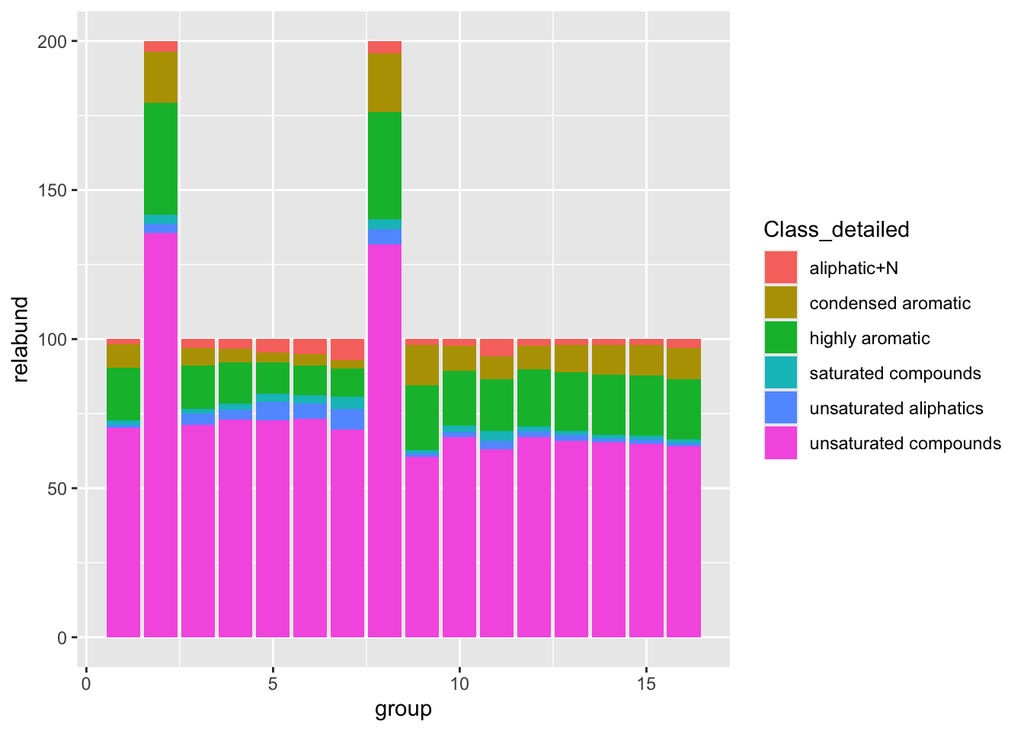

```r
fticr_relabund %>%
  filter(grid == "POOL") %>%
  filter(plot == "Saltwater") %>%
  arrange(collection_datetime) %>%
  group_by(plot, grid, collection_datetime) %>%
  mutate(group= cur_group_id()) %>%
    ggplot(aes(x = group, y = relabund, fill = Class_detailed)) +
    geom_bar(stat = "identity")
```

Looks like maybe the aromatics and condensed aromatics are increasing after the event